# Praca domowa nr 2 z Technik Wizualizacji Danych

Jakub Szypuła

25/10/2019

W poniższym dokumencie zamieszczam moje rozwiązanie zadania nr 2 z TWD, które polegało na poprawieniu wykresu przygotowanego przez inną osobę.

## Oryginalny wykres

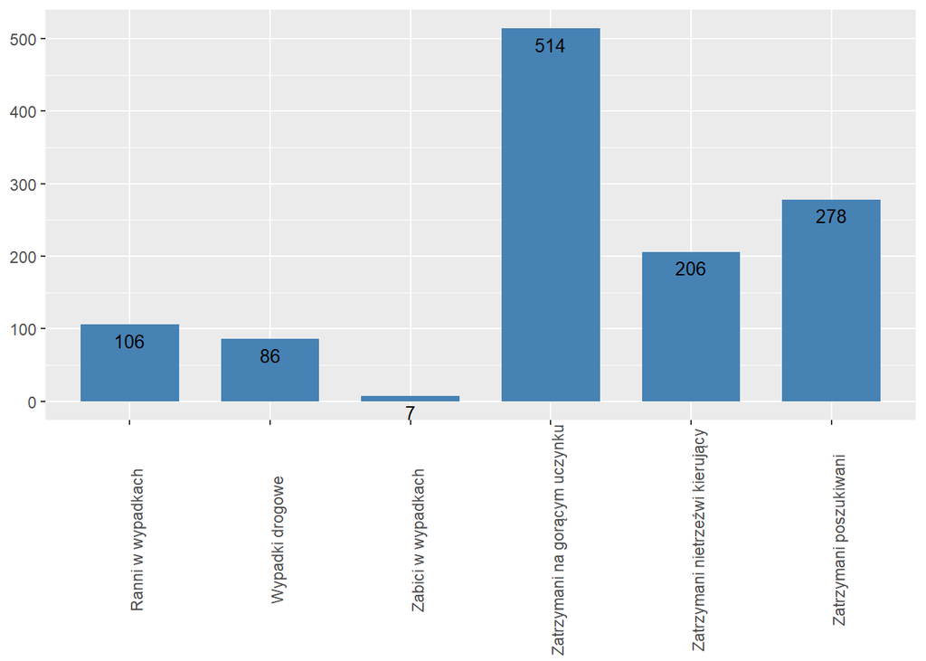

Dane ze strony http://policja.pl/pol/form/r5002806272,07102019.html

## Moja wersja

Tutaj zaś znajduje się moja wersja powyższego wykresu, po zmianach.

[figure not shown]

## Uzasadnienie

Poniżej przedstawiam listę usprawnień, które w mojej opnii powodują, że moja wersja wykresu jest lepsza:

- podpisy osi X: umieszczenie napisów w poziomie oraz zwiększenie rozmiaru czcionki poprawia czytelność wykresu.
- usunięcie wszystkich elementów siatki z wyłączeniem linii poziomych na wysokości 200 i 400: linie pionowe nie są potrzebne w przypadku tak prostego histogramu, pomniejsze linie poziome są zbędne, ponieważ przy każdej kolumnie znajduje się liczba z dokładną jej wartością (linie na poziomie 200 i 400 pozwalają łatwiej rozdzielić wartości na te występujące znacznie częściej i znacznie rzadziej). Zmiana koloru na czarny ułatwia zauważenie jej
- przeniesienie liczby ponad kolumnę, na szarym tle jest lepszy kontrast, dzięki czemu łatwiej ją odczytać; zwiększenie rozmiaru czcionki tej liczby, żeby była lepiej widoczna
- dodanie ikon nad kolumnami, co pozwala na pierwszy rzut oka przypomnieć, co reprezentuje dana kolumna.
- dodanie podpisu osi pionowej
- dodanie loga Policji w pustym miejscu na wykresie, co informuje o pochodzeniu danych i wypełnia puste miejsce na wykresie
- zmiana koloru kolumn na ciemniejszy, jednolity z logiem Policji
- dodanie źródła na dole wykresu
- dodanie tytułu
- zmiana kolejności kolumn z alfabetycznej na malejącą po wartości